# R - Analise de sentimento baseado em tweets

## Analise de sentimento baseado em Tweets

Análise de sentimento desenvolvido em [R Markdown](http://rmarkdown.rstudio.com) Notebook.

Neste projeto, foi realizado a análise de tweets sobre a cooperativa de crédito Sicredi. O Sicredi é uma instituição financeira cooperativa, além de ser referência internacional pelo modelo de atuação, com cerca de 1600 agências espalhadas pelo Brasil. Para conhecer mais sobre a empresa, clique [aqui.](https://www.sicredi.com.br/html/conheca-o-sicredi/quem-somos/?utm_source=menu_topo&utm_medium=topo_site&utm_campaign=quem_somos) Este é um projeto particular utilizando dados públicos e não reflete qualquer opnião pessoal sobre a instituição.

## No projeto, utilizamos a linguagem R versão 3.5.0. Foram utilizadas várias bibliotecas descritas no decorrer o projeto, e como menciona o título do projeto, foi utilizado a rede social Twitter como base na análise.

## Bibliotecas utilizadas

Importando bibliotecas necessárias

```r
require(twitteR)
require(wordcloud)
require(igraph)
library(twitteR)
library(tidyverse)
library(data.table)
library(tidytext)
library(glue)
library(stringr)
library(stringi)
library(rvest)
library(readr)
library(ptstem)
library(wordcloud2)
```

## Realiza o login no twitter

Realizando o login via Oauth no twitter. Os valores dos parametros devem ser recuperados via [Twitter](http://apps.twitter.com)

```r
setup_twitter_oauth(consumer_key = "Gu9aTGl1NTcXX4AEadxOg",
                    consumer_secret = "krz48XjhMg1DGQlB8NtpkWcoIkCss2TtDCg1h02Nao",
                    access_token = "38094175-j6tp3RCXg7ofCMsyDQr0Iimr2lnyPUgLMNQSj4Z6A",
                    access_secret = "guB2pvheBXN09olnQTuAZKimBPr1yyPHNbn8pEUPBji1l")
```

```
[1] "Using direct authentication"
```

Carrega stop words do idioma Pt-BR, encoding UTF-8

```r
stopwordsPage <- read_html("https://www.ranks.nl/stopwords/brazilian", enconding="UTF-8")
stopwordsPage
```

```
{xml_document}
<html lang="en">
[1] <head>\n<title>Brazilian Stopwords</title>\n<link rel="canonical" href="http://www.ranks ...
[2] <body>\r\n\r\n\r\n<div id="wrap">\r\n\r\n<!-- Fixed navbar -->\r\n<div id="nav090bcf1c0a ...
```

```r
stopwordsList <- html_nodes(stopwordsPage,'td')
```

Limpa o HTML, alterando para TAGS

```r
xml_find_all(stopwordsList, ".//br") %>% xml_add_sibling("p", "")
xml_find_all(stopwordsList, ".//br") %>% xml_remove()
swstr <- html_text(stopwordsList)
swstr
```

```
[1] "aaindaalemambasambosantesaoaondeaosaposaqueleaquelesasassimc…"
[2] "essasesseessesestaestasesteesteshaissoistologomaismasmediant…"
[3] "quequemquersesejasemsendoseuseussobsobresuasuastaltambemteuteustodatodastodotodostuatuastudoumumaumasuns"
```

Trata os dados para torna-los dicionarios

```r
sw <- unlist(str_split(swstr,'\\n'))
glimpse(sw)
```

```
 chr [1:3] "aaindaalemambasambosantesaoaondeaosaposaqueleaquelesasassimcomcomocontracontudocujacujascujocujosdadasdedeladel"| __truncated__ ...
```

```r
sw
```

```
[1] "aaindaalemambasambosantesaoaondeaosaposaqueleaquelesasassimc…"
[2] "essasesseessesestaestasesteesteshaissoistologomaismasmediant…"
[3] "quequemquersesejasemsendoseuseussobsobresuasuastaltambemteuteustodatodastodotodostuatuastudoumumaumasuns"
```

```r
library(tm)
```

Carrega stopword da TM, uma ótima biblioeta para mineração de dados em PT.

```r
swList2 <- stopwords('portuguese')
glimpse(swList2)
```

```
 chr [1:203] "de" "a" "o" "que" "e" "do" "da" "em" "um" "para" "com" "não" "uma" "os" "no" ...
```

Realiza o merge usando a biblioteca do tidyverse, extremamento útil para o projeto.

```r
str(sw)
```

```
 chr [1:3] "aaindaalemambasambosantesaoaondeaosaposaqueleaquelesasassimcomcomocontracontudocujacujascujocujosdadasdedeladel"| __truncated__ ...
```

```r
sw_merged <- union(sw,swList2)
summary(sw_merged)
```

```
   Length     Class      Mode
      206 character character
```

```r
#Verifica se temos termos repetidos
tibble(word = sw_merged) %>%
  group_by(word) %>%
  filter(n()>1)
```

| word |
| --- |

## Carregando termos positivos e negativos

Neste momento, foi realizado uma carga em tabela dos arquivos da [Linguateca](http://www.linguateca.pt/Repositorio/ReLi/). Os arquivos foram organizados e salvados no mesmo repositorio de trabalho para facilitar a leitura. Dica:É interessante verificar se os arquivos foram salvos em UTF-8, pois mais a frente enfrentei problemas e tive de voltar e verificar.

```r
#Verificar se os arquivos estão em UTF-8 no notepad++ por ex
an <- read.csv("adjetivos_negativos.txt", header = F, sep = "\t", strip.white = F,
               stringsAsFactors = F, encoding="UTF-8")
exn <- read.csv("expressoes_negativas.txt", header = F, sep = "\t", strip.white = F,
                stringsAsFactors = F, encoding="UTF-8")

vn <- read.csv("verbos_negativos.txt", header = F, sep = "\t", strip.white = F,
               stringsAsFactors = F, encoding="UTF-8")

subn <- read.csv("substantivos_negativos.txt", header = F, sep = "\t", strip.white = F,
                 stringsAsFactors = F, encoding="UTF-8")

ap <- read.csv("adjetivos_positivos.txt", header = F, sep = "\t", strip.white = F,
               stringsAsFactors = F, encoding="UTF-8")

exp <- read.csv("expressoes_positivas.txt", header = F, sep = "\t", strip.white = F,
                stringsAsFactors = F, encoding="UTF-8")

vp <- read.csv("verbos_positivos.txt", header = F, sep = "\t", strip.white = F,
               stringsAsFactors = F, encoding="UTF-8")

sp <- read.csv("substantivos_positivos.txt", header = F, sep = "\t", strip.white = F,
               stringsAsFactors = F, encoding="UTF-8")


str(an);str(exn)
```

[output not shown]

## Carregando termos do Kaggle

No Kaggle também existe um CSV com palavras positivas e negativas. Encontradas [aqui](https://www.kaggle.com/rtatman/sentiment-lexicons-for-81-languages/data)

```r
poskaggle <- read.csv("positive_words_pt.txt", header = F, sep = "\t", strip.white = F,
                      stringsAsFactors = F, encoding="UTF-8")
negkaggle <- read.csv("negative_words_pt.txt", header = F, sep = "\t", strip.white = F,
                      stringsAsFactors = F, encoding="UTF-8")
#imprime para verificação
head(negkaggle)
```

|  | V1 |
| --- | --- |
| 1 | de |
| 2 | sem |
| 3 | tempo |
| 4 | contra |
| 5 | partir |
| 6 | discussão |

Criando um dataframe para guardar as polaridades

```r
dfPolaridades <- an %>%
  mutate(word = V1, polaridade = -1, tipo='adjetivo', sentimento='negativo') %>%
  select(word,polaridade,tipo,sentimento) %>%
  arrange(word)
head(dfPolaridades,2)
```

|  | word | polaridade | tipo | sentimento |
| --- | --- | --- | --- | --- |
| 1 | [anacrônico] | -1 | adjetivo | negativo |
| 2 | [besta] | -1 | adjetivo | negativo |

```r
#Realiza um count para facilitar a inclusao dos dados
pcount <-  length(exn$V1)
dfPolaridades <- bind_rows(dfPolaridades,list(word = exn$V1, polaridade=rep(-1,pcount),tipo=rep('expressao',pcount),sentimento=rep('negativo',pcount)))
dfPolaridades %>% arrange(desc(word)) %>% head(3)
```

|  | word | polaridade | tipo | sentimento |
| --- | --- | --- | --- | --- |
| 1 | Apenas no âmbito cultural | -1 | adjetivo | negativo |
| 2 | [água com açúcar] | -1 | expressao | negativo |
| 3 | [aborrecente] | -1 | adjetivo | negativo |

```r
pcount <-  length(vn$V1)
dfPolaridades <- bind_rows(dfPolaridades,list(word = vn$V1, polaridade=rep(-1,pcount),tipo=rep('verbo',pcount),sentimento=rep('negativo',pcount)))
pcount <-  length(subn$V1)
dfPolaridades <- bind_rows(dfPolaridades,list(word = subn$V1, polaridade=rep(-1,pcount),tipo=rep('substantivo',pcount),sentimento=rep('negativo',pcount)))
pcount <-  length(negkaggle$V1)
dfPolaridades <- bind_rows(dfPolaridades,list(word = negkaggle$V1, polaridade=rep(-1,pcount),tipo=rep('noclass',pcount),sentimento=rep('negativo',pcount)))
pcount <-  length(ap$V1)
dfPolaridades <- bind_rows(dfPolaridades,list(word = ap$V1, polaridade=rep(1,pcount),tipo=rep('adjetivo',pcount),sentimento=rep('positivo',pcount)))
pcount <-  length(exp$V1)
dfPolaridades <- bind_rows(dfPolaridades,list(word = exp$V1, polaridade=rep(1,pcount),tipo=rep('expressao',pcount),sentimento=rep('positivo',pcount)))
pcount <-  length(vp$V1)
dfPolaridades <- bind_rows(dfPolaridades,list(word = vp$V1, polaridade=rep(1,pcount),tipo=rep('verbo',pcount),sentimento=rep('positivo',pcount)))
pcount <-  length(sp$V1)
dfPolaridades <- bind_rows(dfPolaridades,list(word = sp$V1, polaridade=rep(1,pcount),tipo=rep('substantivo',pcount),sentimento=rep('positivo',pcount)))
pcount <-  length(poskaggle$V1)
dfPolaridades <- bind_rows(dfPolaridades,list(word = poskaggle$V1, polaridade=rep(1,pcount),tipo=rep('noclass',pcount),sentimento=rep('positivo',pcount)))
#Visualiza o dataframe
dfPolaridades %>% group_by(word) %>% filter(n() == 1) %>% summarize(n=n())
```

| word | n |
| --- | --- |
| [aborrecer] | 1 |
| [abrir a minha mente] | 1 |
| [adorável] | 1 |
| [agradar] | 1 |
| [agradável] | 1 |
| [água-com-açúcar] | 1 |
| [alegre] | 1 |
| [alucinante] | 1 |
| [amadurecer] | 1 |
| [amar] | 1 |

[output cut: 990 more lines]

```r
dfPolaridades %>% count()
```

| n |
| --- |
| 4565 |

```r
#Remove duplicados
dfPolaridadesUnique <- dfPolaridades[!duplicated(dfPolaridades$word),]
dfPolaridadesUnique %>% count()
```

| n |
| --- |
| 4552 |

## Realizando a busca de tweets

Realiza a busca de tweets. O primeiro parametro é a keyword de busca, e o seugndo é a quantidade de tweets a serem buscados.

```r
tweets <- searchTwitter("sicredi", n = 300)
#Pega os textos dos tweets
tweetxt <- sapply(tweets, function(x) x$getText())
#Vizualizando os dados
tibble(tweetxt)
```

| tweetxt |
| --- |
| #NotíciasRegionais\n\nNessa primeira fase da competição, serão duas datas que sofrerão mudanças no atendimento. https://t.co/t37Jhz48dH |
| https://t.co/fFegYdsInc https://t.co/fFegYdsInc |
| que cartão de crédito débito tu usa ? — O da Sicredi https://t.co/I3xCoQfb2D |
| Sicredi participa do Ciab FEBRABAN 2018 https://t.co/aJ6afFTmgQ |
| Estagiário - Sicredi Várzea Grande https://t.co/Ua0Eiat66B Sicredi\n Location : Várzea Grande MT BR\nO Sicredi de... https://t.co/KR5c6JFObz |
| Comece a sua Poupança Premiada! Poupe, no mínimo, R$ 100 por mês e concorra a diversos prêmios semanais e mensais,… https://t.co/kdIwiIrppp |
| Analista de Comunicação e Marketing - Sede I Nova Petrópolis RS https://t.co/VV5gmeOIYc |
| Caixa - Ponta Grossa - Uvaranas https://t.co/6jHMSKI05y Sicredi\n Location : BR\nObjetivo: Atender os associado... https://t.co/ebhDwtlPkG |
| Espigão Alto - Programa Trator Solidário contempla associados do Sicredi https://t.co/ZJggOLMWNz |
| Só vo no Sicredi pra secar a maquina de cafe deles |

[output cut: 290 more lines]

Realiza uma limpeza dos tweets, retirando @ links e etcs

```r
tweetxtUtf <- NULL
removeURL <- function(x) gsub("http[^[:space:]]*", "", x)
tweetxtUtf <-  readr::parse_character(tweetxt, locale = readr::locale('pt'))
tweetxtUtf <- sapply(tweetxtUtf, function(x) iconv(x, "UTF-8"))
tweetxtUtf <- gsub("(RT|via)((?:\\b\\W*@\\w+)+)", " ",  tweetxtUtf);
tweetxtUtf <- str_replace(tweetxtUtf,"RT @[a-z,A-Z]*: ","")
tweetxtUtf <- gsub("@\\w+", "", tweetxtUtf)
tweetxtUtf <- removeURL(tweetxtUtf)
tweetxtUtf <- str_replace_all(tweetxtUtf,"@[a-z,A-Z]*","")
tweetxtUtf <- gsub("[^[:alnum:][:blank:]!?]", " ", tweetxtUtf)
tweetxtUtf <- gsub("[[:digit:]]", "", tweetxtUtf)
#Verifica como estão os dados
tibble(tweetxtUtf)
```

| tweetxtUtf |
| --- |
| NotíciasRegionais Nessa primeira fase da competição serão duas datas que sofrerão mudanças no atendimento |
| que cartão de crédito débito tu usa ? O da Sicredi |
| Sicredi participa do Ciab FEBRABAN |
| Estagiário Sicredi Várzea Grande Sicredi Location Várzea Grande MT BR O Sicredi de |
| Comece a sua Poupança Premiada! Poupe no mínimo R por mês e concorra a diversos prêmios semanais e mensais |
| Analista de Comunicação e Marketing Sede I Nova Petrópolis RS |
| Caixa Ponta Grossa Uvaranas Sicredi Location BR Objetivo Atender os associado |
| Espigão Alto Programa Trator Solidário contempla associados do Sicredi |
| Só vo no Sicredi pra secar a maquina de cafe deles |

[output cut: 290 more lines]

É interessante remover os tweets duplicados, conforme abaixo

```r
length(tweetxtUtf)
```

```
[1] 300
```

```r
tibble(tweetxtUtf) %>% unique() %>% count()
```

| n |
| --- |
| 245 |

```r
tweetxtUtfUnique <- tweetxtUtf %>% unique()
length(tweetxtUtfUnique)
```

```
[1] 245
```

Removendo as stopwords

```r
#Removendo stopwords
tweetxtUtfUniqueSw <- tm::removeWords(tweetxtUtfUnique,c(sw_merged,'rt'))
tibble(tweetxtUtfUniqueSw)
```

| tweetxtUtfUniqueSw |
| --- |
| NotíciasRegionais Nessa primeira fase competição duas datas sofrerão mudanças atendimento |
| cartão crédito débito usa ? O Sicredi |
| Sicredi participa Ciab FEBRABAN |
| Estagiário Sicredi Várzea Grande Sicredi Location Várzea Grande MT BR O Sicredi |
| Comece Poupança Premiada! Poupe mínimo R mês concorra diversos prêmios semanais mensais |
| Analista Comunicação Marketing Sede I Nova Petrópolis RS |
| Caixa Ponta Grossa Uvaranas Sicredi Location BR Objetivo Atender associado |
| Espigão Alto Programa Trator Solidário contempla associados Sicredi |
| Só vo Sicredi pra secar maquina cafe |

[output cut: 235 more lines]

```r
ttokens <- data_frame(word= tweetxtUtfUniqueSw) %>% unnest_tokens(word,word)
ttokens %>% count(word, sort = T)
```

| word | n |
| --- | --- |
| sicredi | 200 |
| dia | 26 |
| i | 21 |
| é | 20 |
| agência | 19 |
| br | 15 |
| rs | 15 |
| location | 14 |
| negócios | 14 |
| gerente | 13 |

[output cut: 990 more lines]

```r
ttokens_filter <- ttokens %>% filter(nchar(word) > 3)
ttokens_filter %>% count(word, sort=T)
```

| word | n |
| --- | --- |
| sicredi | 200 |
| agência | 19 |
| location | 14 |
| negócios | 14 |
| gerente | 13 |
| banco | 11 |
| grande | 11 |
| nova | 9 |
| ainda | 8 |
| associados | 8 |

[output cut: 873 more lines]

```r
ttokens_freq <- ttokens_filter %>% count(word, sort = T) %>% select(word, freq=n)
ttokens_freq
```

| word | freq |
| --- | --- |
| sicredi | 200 |
| agência | 19 |
| location | 14 |
| negócios | 14 |
| gerente | 13 |
| banco | 11 |
| grande | 11 |
| nova | 9 |
| ainda | 8 |
| associados | 8 |

[output cut: 873 more lines]

## Nuvem de palavras

Agora podemos montar uma nuvem de palavras utilizando o Wordcloud2. Com isso teremos as palavras mais utilizadas maiores e a menos utilizadas menores etc. Incluí varios tipos de núvens para exemplificar.

```r
require(devtools)
library(wordcloud2)
#Tive problemas e foi necessario instalar a partir do repositorio
#FicaDica
#install_github("lchiffon/wordcloud2")
figPath = system.file("examples/t.png",package = "wordcloud2")
#nuvem com imagem twitter
wordcloud2(ttokens_freq, figPath = figPath,minSize = 2, size = 1.5,color = "skyblue")
```

[interactive chart not shown]

```r
#nuvem tradicional
wordcloud2(ttokens_freq , minSize = 2, size = 3, backgroundColor = 'gray')
```

[interactive chart not shown]

```r
#rotacao
wordcloud2(ttokens_freq, minRotation = -pi/6, maxRotation = -pi/6, minSize = 10,
           rotateRatio = 1)
```

[interactive chart not shown]

```r
#outro tipo
wordcloud2(ttokens_freq, color = "random-light", backgroundColor = "grey", minSize = 2,size = 1)
```

[interactive chart not shown]

Resolvi salvar os datasets para continuar o trabalho posteriormente sem perder nada.

```r
write_csv(tibble(word = sw_merged),path = 'stopwords.csv')
write_csv(as.tibble(dfPolaridadesUnique),path = 'polaridades_pt.csv')
write_csv(tibble(tweet = tweetxt),path = 'tweetxt.csv')
write_csv(tibble(tweet = tweetxtUtfUniqueSw),path='tweets_limpo.csv')
write_csv(ttokens_freq, path='tokens.csv')
```

Carregando as polaridades (não necessario para execucao linear do codigo)

```r
polaridades_pt <- read_csv('polaridades_pt.csv')
stopwordslist <- read_csv('stopwords.csv')
stopwordslist
```

| word |
| --- |
| aaindaalemambasambosantesaoaondeaosaposaqueleaquelesasassimc…… |
| essasesseessesestaestasesteesteshaissoistologomaismasmediant…… |
| quequemquersesejasemsendoseuseussobsobresuasuastaltambemteuteustodatodastodotodostuatuastudoumumaumasuns |
| de |
| a |
| o |
| que |
| e |
| do |
| da |

[output cut: 196 more lines]

É imprescindivel utilizar a funcao enc2native, pois do contrario o TM vai destruír seu dataset.

```r
tweetencoded <- sapply(tweetxtUtfUnique,enc2native)
tibble(tweetencoded)
```

| tweetencoded |
| --- |
| NotíciasRegionais Nessa primeira fase da competição serão duas datas que sofrerão mudanças no atendimento |
| que cartão de crédito débito tu usa ? O da Sicredi |
| Sicredi participa do Ciab FEBRABAN |
| Estagiário Sicredi Várzea Grande Sicredi Location Várzea Grande MT BR O Sicredi de |
| Comece a sua Poupança Premiada! Poupe no mínimo R por mês e concorra a diversos prêmios semanais e mensais |
| Analista de Comunicação e Marketing Sede I Nova Petrópolis RS |
| Caixa Ponta Grossa Uvaranas Sicredi Location BR Objetivo Atender os associado |
| Espigão Alto Programa Trator Solidário contempla associados do Sicredi |
| Só vo no Sicredi pra secar a maquina de cafe deles |

[output cut: 235 more lines]

```r
# TIRA VALORES NULOS - Caso fique nulos, teremos erro logo a frente
dd <- tweetencoded %>% na.omit()
##drop_na(tweetencoded)
tibble(dd)
```

| dd |
| --- |
| NotíciasRegionais Nessa primeira fase da competição serão duas datas que sofrerão mudanças no atendimento |
| que cartão de crédito débito tu usa ? O da Sicredi |
| Sicredi participa do Ciab FEBRABAN |
| Estagiário Sicredi Várzea Grande Sicredi Location Várzea Grande MT BR O Sicredi de |
| Comece a sua Poupança Premiada! Poupe no mínimo R por mês e concorra a diversos prêmios semanais e mensais |
| Analista de Comunicação e Marketing Sede I Nova Petrópolis RS |
| Caixa Ponta Grossa Uvaranas Sicredi Location BR Objetivo Atender os associado |
| Espigão Alto Programa Trator Solidário contempla associados do Sicredi |
| Só vo no Sicredi pra secar a maquina de cafe deles |

[output cut: 234 more lines]

```r
df <- data.frame(text=dd)
head(df)
```

|  | text |
| --- | --- |
| NotíciasRegionais Nessa primeira fase da competição serão duas datas que sofrerão mudanças no atendimento | NotíciasRegionais Nessa primeira fase da competição serão duas datas que sofrerão mudanças no atendimento |
| que cartão de crédito débito tu usa ? O da Sicredi | que cartão de crédito débito tu usa ? O da Sicredi |
| Sicredi participa do Ciab FEBRABAN | Sicredi participa do Ciab FEBRABAN |
| Estagiário Sicredi Várzea Grande Sicredi Location Várzea Grande MT BR O Sicredi de | Estagiário Sicredi Várzea Grande Sicredi Location Várzea Grande MT BR O Sicredi de |
| Comece a sua Poupança Premiada! Poupe no mínimo R por mês e concorra a diversos prêmios semanais e mensais | Comece a sua Poupança Premiada! Poupe no mínimo R por mês e concorra a diversos prêmios semanais e mensais |

Cria um id para o documento e verifica os dados. Logo após, criamos o corpus e o DTM com a frequencia desejada. Com isso, verificamos os termos mais frequentes do nosso dataset.

```r
df$doc_id <- row.names(df)
head(df)
```

|  | text | doc_id |
| --- | --- | --- |
| NotíciasRegionais Nessa primeira fase da competição serão duas datas que sofrerão mudanças no atendimento | NotíciasRegionais Nessa primeira fase da competição serão duas datas que sofrerão mudanças no atendimento | NotíciasRegionais Nessa primeira fase da competição serão duas datas que sofrerão mudanças no atendimento |
| que cartão de crédito débito tu usa ? O da Sicredi | que cartão de crédito débito tu usa ? O da Sicredi | que cartão de crédito débito tu usa ? O da Sicredi |
| Sicredi participa do Ciab FEBRABAN | Sicredi participa do Ciab FEBRABAN | Sicredi participa do Ciab FEBRABAN |
| Estagiário Sicredi Várzea Grande Sicredi Location Várzea Grande MT BR O Sicredi de | Estagiário Sicredi Várzea Grande Sicredi Location Várzea Grande MT BR O Sicredi de | Estagiário Sicredi Várzea Grande Sicredi Location Várzea Grande MT BR O Sicredi de |
| Comece a sua Poupança Premiada! Poupe no mínimo R por mês e concorra a diversos prêmios semanais e mensais | Comece a sua Poupança Premiada! Poupe no mínimo R por mês e concorra a diversos prêmios semanais e mensais | Comece a sua Poupança Premiada! Poupe no mínimo R por mês e concorra a diversos prêmios semanais e mensais |

```r
tm_corpus <- Corpus(DataframeSource(df))
inspect(tm_corpus[1:10])
```

```
<<SimpleCorpus>>
Metadata:  corpus specific: 1, document level (indexed): 0
Content:  documents: 10

    NotíciasRegionais  Nessa primeira fase da competição  serão duas datas que sofrerão mudanças no atendimento
    NotíciasRegionais  Nessa primeira fase da competição  serão duas datas que sofrerão mudanças no atendimento


                                                            que cartão de crédito débito tu usa ?   O da Sicredi
                                                            que cartão de crédito débito tu usa ?   O da Sicredi
                                                                             Sicredi participa do Ciab FEBRABAN
                                                                             Sicredi participa do Ciab FEBRABAN
                     Estagiário   Sicredi Várzea Grande  Sicredi  Location   Várzea Grande MT BR O Sicredi de
                     Estagiário   Sicredi Várzea Grande  Sicredi  Location   Várzea Grande MT BR O Sicredi de
Comece a sua Poupança Premiada! Poupe  no mínimo  R   por mês e concorra a diversos prêmios semanais e mensais
Comece a sua Poupança Premiada! Poupe  no mínimo  R   por mês e concorra a diversos prêmios semanais e mensais
                                                 Analista de Comunicação e Marketing   Sede I Nova Petrópolis RS
                                                 Analista de Comunicação e Marketing   Sede I Nova Petrópolis RS
                     Caixa   Ponta Grossa   Uvaranas  Sicredi  Location     BR Objetivo  Atender os associado
                     Caixa   Ponta Grossa   Uvaranas  Sicredi  Location     BR Objetivo  Atender os associado
                                        Espigão Alto   Programa Trator Solidário contempla associados do Sicredi
                                        Espigão Alto   Programa Trator Solidário contempla associados do Sicredi
                                                               Só vo no Sicredi pra secar a maquina de cafe deles
                                                               Só vo no Sicredi pra secar a maquina de cafe deles
```

```r
dtm <- DocumentTermMatrix(tm_corpus, control=list(wordLengths=c(4, 20), language=locale('pt'), stopwords=stopwords('portuguese')))
dtm <- DocumentTermMatrix(tm_corpus, control=list(wordLengths=c(4,20),
                                                  language=locale('pt'),
                                                  stopwords=stopwords('portuguese'),
                                                  bounds = list(global = c(3,500))))
dtm
```

```
<<DocumentTermMatrix (documents: 244, terms: 97)>>
Non-/sparse entries: 633/23035
Sparsity           : 97%
Maximal term length: 11
Weighting          : term frequency (tf)
```

```r
#termos mais frequentes
findFreqTerms(dtm)
```

```
 [1] "atendimento" "primeira"    "cartão"      "débito"      "sicredi"     "ciab"
 [7] "grande"      "location"    "prêmios"     "nova"        "associado"   "atender"
[13] "caixa"       "objetivo"    "alto"        "associados"  "contempla"   "solidário"
[19] "trator"      "quer"        "centro"      "sorteia"     "copa"        "redes"
[25] "sociais"     "banco"       "melhor"      "projetos"    "feira"       "atuação"
[31] "educação"    "financeira"  "nacional"    "semana"      "triplica"    "gerente"
[37] "negócios"    "porto"       "assistente"  "financeiro"  "ainda"       "quase"
[43] "preciso"     "participar"  "café"        "campanha"    "população"   "parceria"
[49] "aqui"        "aliança"     "marechal"    "rondon"      "segurança"   "nesta"
[55] "agência"     "pessoa"      "dinheiro"    "você"        "evento"      "hoje"
[61] "conheça"     "está"        "gente"       "fundo"       "inscrições"  "região"
[67] "brasil"      "sobre"       "deus"        "marau"       "segunda"     "três"
[73] "noite"       "stand"       "marcelo"     "novos"       "entrega"     "cadastre"
[79] "currículo"   "processo"    "vaga"        "agora"       "tava"        "filme"
[85] "homenagem"   "lança"       "namorados"   "amor"        "renda"       "anos"
[91] "toda"        "conta"       "simples"     "sempre"      "cidade"      "concurso"
[97] "empréstimo"
```

```r
ttm_results <- t(as.matrix(dtm)) %*% as.matrix(dtm)
head(ttm_results)
```

```
             Terms
Terms         atendimento primeira cartão débito sicredi ciab grande location prêmios nova
  atendimento           6        1      0      0       5    0      0        2       0    0
  primeira              1        4      0      0       3    0      1        0       0    0
  cartão                0        0      4      3       4    0      0        0       0    0
  débito                0        0      3      3       3    0      0        0       0    0
  sicredi               5        3      4      3     220    2     15       18       3    8
  ciab                  0        0      0      0       2    5      0        0       0    1
             Terms
Terms         associado atender caixa objetivo alto associados contempla solidário trator quer
  atendimento         1       0     0        1    0          1         0         0      0    0
  primeira            0       0     0        0    0          0         0         0      0    0
  cartão              0       0     0        0    0          0         0         0      0    0
  débito              0       0     0        0    0          0         0         0      0    0
  sicredi             4       3     9        6    3          7         3         3      4    1
  ciab                0       0     0        0    0          0         0         0      0    0
             Terms
Terms         centro sorteia copa redes sociais banco melhor projetos feira atuação educação
  atendimento      0       0    1     0       0     0      0        0     0       0        0
  primeira         0       0    0     0       0     0      0        0     0       0        0
  cartão           0       0    0     0       0     0      0        0     0       0        0
  débito           0       0    0     0       0     0      0        0     0       0        0
  sicredi          8       4    3     0       2    11      2        2     5       7        8
  ciab             0       0    0     0       0     0      0        0     0       0        0
             Terms
Terms         financeira nacional semana triplica gerente negócios porto assistente financeiro
  atendimento          0        0      0        0       0        0     0          2          0
  primeira             0        0      0        0       0        0     0          0          0
  cartão               0        0      0        0       0        0     0          0          0
  débito               0        0      0        0       0        0     0          0          0
  sicredi              3        7      5        4       9       13     7          3          3
  ciab                 0        0      0        0       0        0     0          0          0
             Terms
Terms         ainda quase preciso participar café campanha população parceria aqui aliança
  atendimento     0     0       0          0    0        0         0        0    0       0
  primeira        1     1       0          0    0        0         0        0    0       0
  cartão          0     0       0          0    0        0         0        0    0       0
  débito          0     0       0          0    0        0         0        0    0       0
  sicredi         6     3       2          0    4        4         4        5    4       4
  ciab            0     0       0          0    0        0         0        0    0       0
```

[output cut: 25 more lines]

```
Terms         homenagem lança namorados amor renda anos toda conta simples sempre cidade
  atendimento         0     0         0    0     0    0    0     0       0      0      1
  primeira            0     0         0    0     0    0    0     0       0      0      0
  cartão              0     0         0    0     0    0    0     0       0      0      0
  débito              0     0         0    0     0    0    0     0       0      0      0
  sicredi             5     5         6    2     1    3    3     9       4      3      3
  ciab                0     0         0    0     0    0    0     0       0      0      0
             Terms
Terms         concurso empréstimo
  atendimento        0          0
  primeira           0          0
  cartão             0          0
  débito             0          0
  sicredi            2          3
  ciab               0          0
```

Agora, vamos contruir o gráfico e os degrees dos vertices para vizualiação dos dados.

```r
library(igraph)
g <- graph.adjacency(ttm_results, weighted=T, mode = 'undirected')
g <- simplify(g)
V(g)$label <- V(g)$name
V(g)$degree <- degree(g)
E(g)$color <- ifelse(E(g)$wheight > 15, "lightblue", "red")
```

[output not shown]

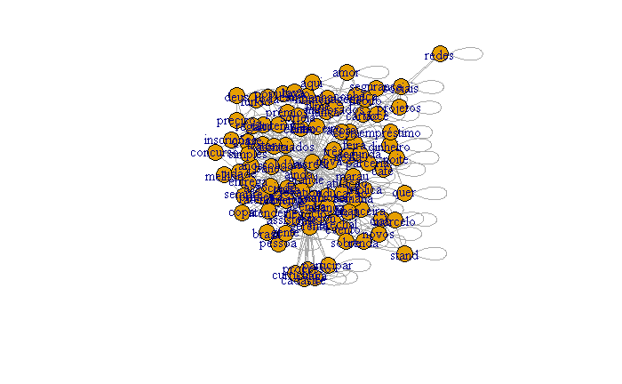

```r
set.seed(2000)
par(bg = 'white')
layout1 <- layout_on_sphere(g)
plot(g, layout=layout.fruchterman.reingold)
```

Criando um tibble com labels das qualificações e verificar as quantidade de termos em gráfico

```r
library(quanteda)
twdf <- tibble(tweet = tweetxtUtfUnique)
twdf$whois <- NA
twdf$whois[twdf$tweet %like% 'sicredi'] <- 'sicredi'
twdf$whois[twdf$tweet %like% 'agência'] <- 'agencia'
twdf$whois[twdf$tweet %like% 'gerente'] <- 'gerente'
twdf$whois[twdf$tweet %like% 'negócios'] <- 'negocios'
twdf$whois[twdf$tweet %like% 'banco'] <- 'banco'
twdf$whois[twdf$tweet %like% 'simples'] <- 'simples'
twdf$whois[twdf$tweet %like% 'melhor'] <- 'melhor'
twdf$whois[twdf$tweet %like% 'juntos'] <- 'juntos'
# cria uma qualificação sem_tag como vala comum no dataset
twdf$whois[is.na(twdf$whois) ] <- 'semtag'
freq <- twdf %>% count(whois, sort = T) %>% select( whois,freq = n)
freq
```

| whois | freq |
| --- | --- |
| semtag | 180 |
| sicredi | 38 |
| agencia | 11 |
| banco | 5 |
| melhor | 5 |
| simples | 3 |
| gerente | 2 |
| juntos | 1 |

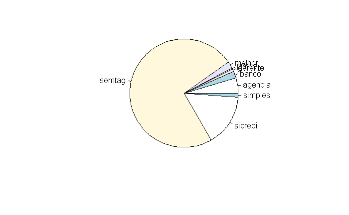

```r
#plotando essa loucura
pie(table(twdf$whois))
```

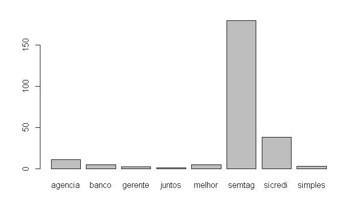

```r
#grafico em barras
barplot(table(twdf$whois))
```

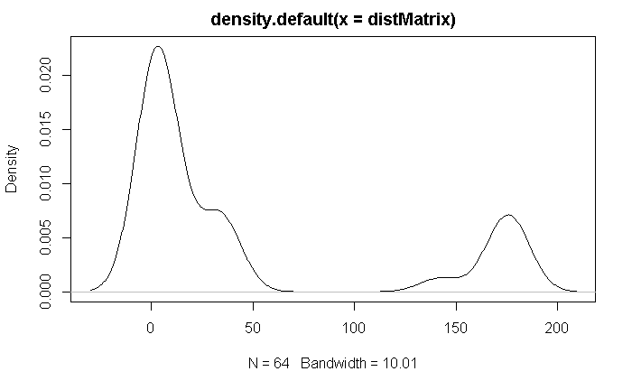

```r
#verificando a densidade dos termos
distMatrix <- as.matrix(dist(freq$freq))
plot(density(distMatrix))
```

## Matriz de termos por documento

Esta é uma parte importante na analise. Vamos criar a matriz de termos por documento para analisar os tweets. Utilizaremos a library quanteda, que tambem é utilizada para tokenizar os textos. Ele tambem converte os dados e realiza uma limpeza, como retirar pontuação, converte tudo para minusculo dentre outras funções.

```r
dfq <- data.frame(id=row.names(twdf),
                  text=twdf$tweet, whois = factor(twdf$whois))
myCorpus <- corpus(twdf,  text_field = 'tweet',
                   metacorpus = list(source = "tweets sobre o sicredi"))
myCorpus
```

```
Corpus consisting of 245 documents and 1 docvar.
```

```r
#validando legibilidade
head(textstat_readability(myCorpus),2)
```

|  | document | ARI | ARI.simple | Bormuth | Bormuth.GP | Coleman | Coleman.C2 | Coleman.Liau | Coleman.Liau.grade | Coleman.Liau.short | Dale.Chall | Dale.Chall.old | Dale.Chall.PSK | Danielson.Bryan | Danielson.Bryan.2 | Dickes.Steiwer | DRP | ELF | Farr.Jenkins.Paterson | Flesch | Flesch.PSK | Flesch.Kincaid | FOG | FOG.PSK | FOG.NRI | FORCAST | FORCAST.RGL | Fucks | Linsear.Write | … |
| --- | --- | --- | --- | --- | --- | --- | --- | --- | --- | --- | --- | --- | --- | --- | --- | --- | --- | --- | --- | --- | --- | --- | --- | --- | --- | --- | --- | --- | --- | --- |
| 1 | text1 | 16.52143 | 73.14286 | -2.397898 | 35381986.5 | -1.592857 | 5.764286 | 8.536757 | 20.724844 | 20.72571 | -40.66 | 20.1209 | 15.6516 | 8.513423 | 59.49857 | -469.8266 | 339.7898 | 10.0 | -45.27014 | -18.875 | 10.2613 | 19.37 | 22.74286 | 7.984033 | 0.32 | 15.71429 | 15.71571 | 92.0 | 24 | … |
| 2 | text3 | -0.56100 | 40.10000 | -0.333942 | -397083.3 | 26.050000 | 49.650000 | 79.746240 | 1.213161 | 1.21200 | -34.45 | 19.6745 | 15.1152 | 4.263467 | 86.52663 | -161.6768 | 133.3942 | 2.5 | -35.79250 | 57.940 | 5.9211 | 6.42 | 10.00000 | 3.313318 | -1.15 | 12.50000 | 12.18000 | 19.5 | 4 | … |

```r
#validando
summary(myCorpus,6)
```

```
Corpus consisting of 245 documents, showing 6 documents:

  Text Types Tokens Sentences  whois
 text1    14     14         1 semtag
 text2     0      0         0 semtag
 text3    11     11         2 semtag
 text4     5      5         1 semtag
 text5     9     13         1 semtag
 text6    18     20         2 semtag

Source: tweets sobre o sicredi
Created: Sat Jun 16 14:25:11 2018
Notes:
```

```r
#tokenizando o texto
temptok <- tokens(tweetxtUtfUnique)
#verificando
temptok[1:5]
```

```
tokens from 5 documents.
text1 :
 [1] "NotíciasRegionais" "Nessa"             "primeira"          "fase"
 [5] "da"                "competição"        "serão"             "duas"
 [9] "datas"             "que"               "sofrerão"          "mudanças"
[13] "no"                "atendimento"

text2 :
character(0)

text3 :
 [1] "que"     "cartão"  "de"      "crédito" "débito"  "tu"      "usa"     "?"       "O"
[10] "da"      "Sicredi"

text4 :
[1] "Sicredi"   "participa" "do"        "Ciab"      "FEBRABAN"

text5 :
 [1] "Estagiário" "Sicredi"    "Várzea"     "Grande"     "Sicredi"    "Location"   "Várzea"
 [8] "Grande"     "MT"         "BR"         "O"          "Sicredi"    "de"
```

```r
remove(temptok)
#utilizando o quanteda
myDfm <- dfm(myCorpus, stem = F)
myDfm
```

```
Document-feature matrix of: 245 documents, 1,089 features (98.9% sparse).
```

```r
topfeatures(myDfm,20)
```

```
sicredi      de      do       e       o       a     que      no      em     com      na
    200     102      74      58      53      49      48      46      37      37      34
   para      da     dia       !       i      um       é    mais agência
     33      32      26      21      21      21      20      19      19
```

```r
stopwors2 <- c('the','r','é','c','?','!','of','rt','pra')
myDfm <- dfm(myCorpus, groups='whois', remove = c(quanteda::stopwords("portuguese"),stopwors2,tm::stopwords('portuguese')),
             stem = F, remove_punct = TRUE)
#ele agrupa pela qualificação
myDfm
```

```
Document-feature matrix of: 8 documents, 979 features (85.8% sparse).
```

Vamos verificar a frequencia no texto

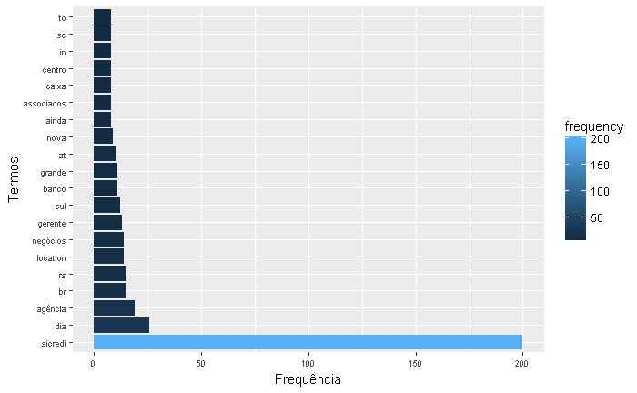

```r
#frequencia do texto
allfeats <- textstat_frequency(myDfm)
allfeats$feature <- with(allfeats, reorder(feature, -frequency))
#vizualizando os termos por frequencia
ggplot(head(allfeats,20), aes(x=feature, y=frequency, fill=frequency)) + geom_bar(stat="identity") +
  xlab("Termos") + ylab("Frequência") + coord_flip() +
  theme(axis.text=element_text(size=7))
```

```r
#termos mais frequentes do dataset
col <- textstat_collocations(myCorpus , size = 2:4, min_count = 2)
head(col)
```

|  | collocation | count | count_nested | length | lambda | z |
| --- | --- | --- | --- | --- | --- | --- |
| 1 | do sicredi | 29 | 29 | 2 | 2.725728 | 10.558904 |
| 2 | no sicredi | 22 | 22 | 2 | 2.995092 | 9.682065 |
| 3 | dia dos | 9 | 9 | 2 | 5.889632 | 9.402332 |
| 4 | RS SC | 5 | 5 | 2 | 6.468705 | 8.203670 |
| 5 | i m | 10 | 10 | 2 | 7.480428 | 8.078014 |
| 6 | o sicredi | 18 | 18 | 2 | 2.378350 | 7.863830 |

```r
topfeatures(myDfm, 20)
```

```
   sicredi        dia    agência         br         rs   location   negócios    gerente
       200         26         19         15         15         14         14         13
       sul     grande      banco         at       nova      caixa associados     centro
        12         11         11         10          9          8          8          8
        in         to      ainda         sc
         8          8          8          8
```

```r
set.seed(100)
```

## Realizando a vizualicação dos termos mais frequentes!

```
min.freqcolorsrandom.orderrot.per is deprecated; use min_countcolorrandom_orderrotation instead
```

[figure not shown]

```r
#plotando os termos!
textplot_wordcloud(myDfm, min.freq = 15, random.order = FALSE,
                   rot.per = .6,
                   colors = RColorBrewer::brewer.pal(8,"Dark2"))
```

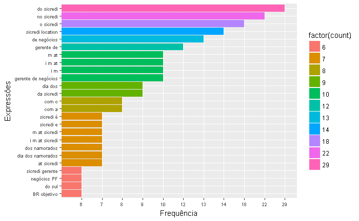

```r
#grafico por cores
ggplot(col[order(col$count, decreasing = T),][1:25,],
       aes(x=reorder(collocation,count), y=factor(count), fill=factor(count))) + geom_bar(stat="identity") +
  xlab("Expressões") + ylab("Frequência")  + coord_flip() +
  theme(axis.text=element_text(size=7))
```

Vamos vizualizar a relação entre as tags encontradas no dataset

```r
##########################
twraw <- readr::parse_character(tweetxt, locale = readr::locale('pt'))
mytoken <- tokens(twraw,
                  remove_numbers=T,remove_symbols=T,
                  remove_twitter=T, remove_url=T)
```

```
remove_twitter reset to FALSE when remove_punct = FALSE
```

```r
head(mytoken)
```

```
tokens from 6 documents.
text1 :
 [1] "#NotíciasRegionais" "Nessa"              "primeira"           "fase"
 [5] "da"                 "competição"         ","                  "serão"
 [9] "duas"               "datas"              "que"                "sofrerão"
[13] "mudanças"           "no"                 "atendimento"        "."

text2 :
character(0)

text3 :
 [1] "que"     "cartão"  "de"      "crédito" "débito"  "tu"      "usa"     "?"       "-"
[10] "O"       "da"      "Sicredi"

text4 :
[1] "Sicredi"   "participa" "do"        "Ciab"      "FEBRABAN"

text5 :
 [1] "Estagiário" "-"          "Sicredi"    "Várzea"     "Grande"     "Sicredi"    "Location"
 [8] ":"          "Várzea"     "Grande"     "MT"         "BR"         "O"          "Sicredi"
[15] "de"         "."          "."          "."

text6 :
 [1] "Comece"   "a"        "sua"      "Poupança" "Premiada" "!"        "Poupe"    ","
 [9] "no"       "mínimo"   ","        "R"        "por"      "mês"      "e"        "concorra"
[17] "a"        "diversos" "prêmios"  "semanais" "e"        "mensais"  ","        "…"
```

```r
##
mytoken <- tokens_remove(mytoken, stopwords('portuguese'))
head(textstat_collocations(mytoken,size = 5, min_count = 5))
```

|  | collocation | count | count_nested | length | lambda | z |
| --- | --- | --- | --- | --- | --- | --- |
| 1 | at banco sicredi in dom | 6 | 0 | 5 | 3.948421 | 0.5502476 |
| 2 | banco sicredi in dom pedrito | 6 | 0 | 5 | 2.982601 | 0.4022334 |
| 3 | sicredi lança filme homenagem dia | 8 | 0 | 5 | 2.855981 | 0.3805598 |
| 4 | sicredi centro-sul MS sorteia prêmios | 5 | 0 | 5 | 1.153468 | 0.1566744 |
| 5 | i'm at banco sicredi in | 6 | 0 | 5 | 0.311888 | 0.0427250 |
| 6 | centro-sul MS sorteia prêmios associados | 5 | 0 | 5 | -0.919115 | -0.1229133 |

```r
#
myrawCorpus <- corpus(twraw)
tweetdfm <- dfm(myrawCorpus, remove_punct = TRUE)
tagdfm <- dfm_select(tweetdfm, ('#*'))
toptag <- names(topfeatures(tagdfm, 50))
head(toptag)
```

```
[1] "#sicredi"           "#notíciasregionais" "#decarona"          "#lojasqueroquero"
[5] "#gfteaws"           "#abelhuda"
```

```r
#
tagfcm <- fcm(tagdfm)
head(tagfcm)
```

```
Feature co-occurrence matrix of: 6 by 6 features.
6 x 6 sparse Matrix of class "fcm"
                    features
features             #notíciasregionais #abelhuda #engeplus #novapauta #sicredi #coooerar
  #notíciasregionais                  0         0         0          0        0         0
  #abelhuda                           0         0         0          0        0         0
  #engeplus                           0         0         0          0        0         0
  #novapauta                          0         0         0          0        0         0
  #sicredi                            0         0         0          0        0         1
  #coooerar                           0         0         0          0        0         0
```

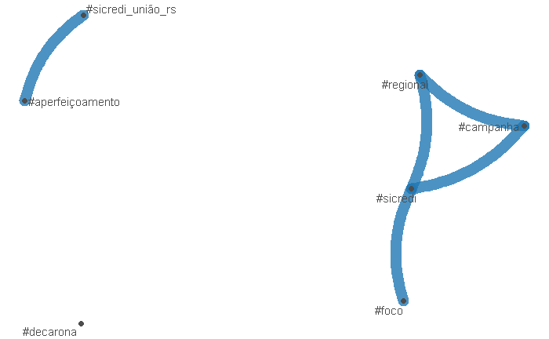

```r
toptagfcm <- fcm_select(tagfcm, toptag)
textplot_network(toptagfcm, min_freq = 0.1, edge_alpha = 0.8, edge_size = 5)
```

Vizualizando a relação entre os usuarios que originaram o dataset

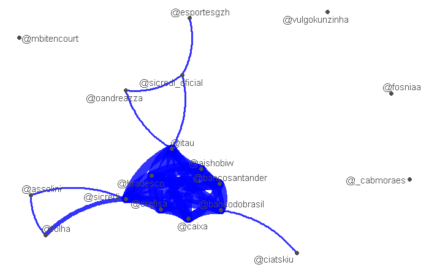

```r
## criando um grafico de relação de usuarios
userdfm <- dfm_select(tweetdfm, ('@*'))
topuser <- names(topfeatures(userdfm, 200))
userfcm <- fcm(userdfm)
userfcm <- fcm_select(userfcm, topuser)
textplot_network(userfcm, min_freq = 0.1, edge_color = 'blue', edge_alpha = 0.8, edge_size = 5)
```

```r
#criando o dtm com as polaridade positivas e negativas
positivas <- polaridades_pt %>% filter(sentimento == 'positivo') %>% select(word)
negativas <- polaridades_pt %>% filter(sentimento == 'negativo') %>% select(word)
dic <- dictionary(list(positivas=as.character(positivas$word), negativas=as.character(negativas$word)))
bySentimento <- dfm(myCorpus, dictionary = dic)
library(tidytext)
scorebygroup <- tidy(bySentimento %>%
                       dfm_group(groups='whois') )
scorebygroup
```

| document | term | count |
| --- | --- | --- |
| agencia | positivas | 11 |
| banco | positivas | 6 |
| juntos | positivas | 1 |
| melhor | positivas | 14 |
| semtag | positivas | 103 |
| sicredi | positivas | 16 |
| simples | positivas | 3 |
| agencia | negativas | 7 |
| banco | negativas | 8 |
| juntos | negativas | 3 |

[output cut: 4 more lines]

## Analise de sentimento

Vamos realizar agora a análise de sentimento do nosso dataset.

```r
#salvando o dataframe
twdf %>% write_csv(path='twittersentimentaldata.csv')
twdf <- read_csv('twittersentimentaldata.csv')
twdf$id <- rownames(twdf)
tw <- twdf %>% mutate(document = id,word=tweet) %>% select(document,word,whois)
#
str(tw)
```

```
Classes ‘tbl_df’, ‘tbl’ and 'data.frame':   245 obs. of  3 variables:
 $ document: chr  "1" "2" "3" "4" ...
 $ word    : chr  "NotíciasRegionais  Nessa primeira fase da competição  serão duas datas que sofrerão mudanças no atendimento" NA "que cartão de crédito débito tu usa ?   O da Sicredi" "Sicredi participa do Ciab FEBRABAN" ...
 $ whois   : chr  "semtag" "semtag" "semtag" "semtag" ...
```

```r
tdm <- tw %>% unnest_tokens(word,word)
#removendo stop words carregadas
tdm <- tdm %>% anti_join(data.frame(word= stopwords('portuguese')))
```

```
Column `word` joining character vector and factor, coercing into character vector
```

```r
tdm <- tdm %>% anti_join(data.frame(word= stopwors2))
```

```
Column `word` joining character vector and factor, coercing into character vector
```

```r
head(tdm)
```

| document | word | whois |
| --- | --- | --- |
| 1 | notíciasregionais | semtag |
| 1 | nessa | semtag |
| 1 | primeira | semtag |
| 1 | fase | semtag |
| 1 | competição | semtag |
| 1 | duas | semtag |

## Realizando a vizualição das primeiras impressões da análise

Vamos plotar os dados, e em seguida ajustar os dados para vizualiar a porcentagem e as palavras mais utilizadas por sentimento.

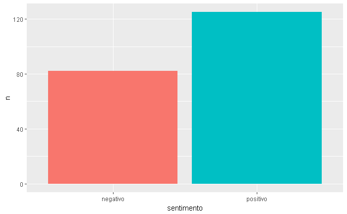

```r
library(tidyr)
sentJoin <- tdm %>%
  inner_join(polaridades_pt, by='word')
sentJoin %>%
  count(sentimento) %>%
  ggplot(aes(sentimento,n , fill = sentimento)) +
  geom_bar(stat = "identity", show.legend = FALSE)
```

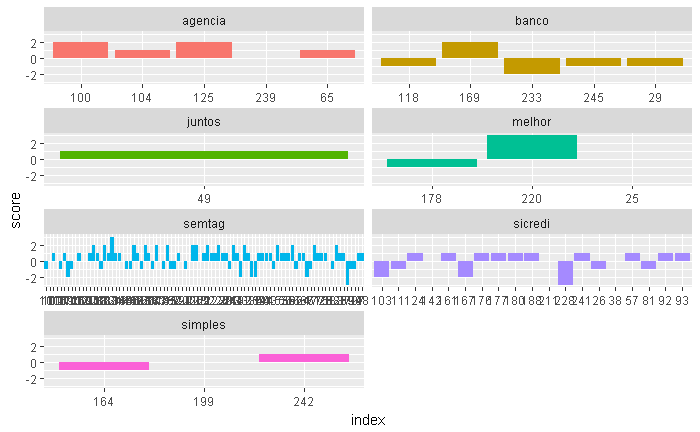

```r
###
sentJoin %>%
  count(whois, index = document, sentimento) %>%
  spread(sentimento, n, fill = 0) %>%
  mutate(score = positivo - negativo) %>%
  ggplot(aes(index, score, fill = whois)) +
  geom_bar(stat = "identity", show.legend = FALSE) +
  facet_wrap(~whois, ncol = 2, scales = "free_x")
```

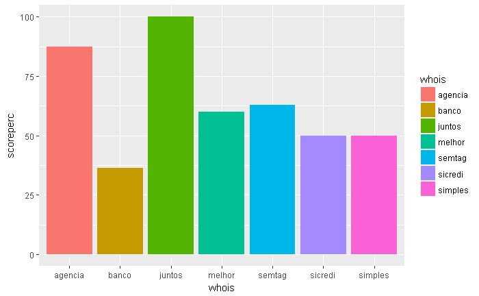

```r
##ajusta para buscar a porcentagem
scored <- sentJoin %>%
  count(whois,sentimento) %>%
  spread(sentimento, n, fill = 0) %>%
  mutate(score = positivo -negativo) %>%
  mutate(scoreperc = (positivo / (positivo + negativo)) * 100)
#plota
ggplot(scored, aes(whois,scoreperc , fill = whois)) +
  geom_bar(stat = "identity", show.legend = T)
```

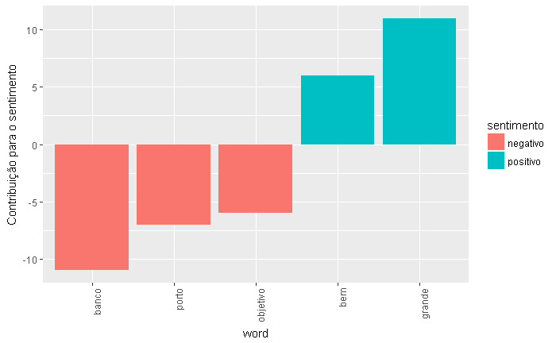

```r
#palavras por sentimento
word_counts <- sentJoin %>%
  count(word, sentimento, sort = TRUE) %>%
  ungroup()
word_counts %>%
  filter(n > 5) %>%
  mutate(n = ifelse(sentimento == "negativo", -n, n)) %>%
  mutate(word = reorder(word, n)) %>%
  ggplot(aes(word, n, fill = sentimento)) +
  geom_bar(stat = "identity") +
  theme(axis.text.x = element_text(angle = 90, hjust = 1)) +
  ylab("Contribuição para o sentimento")
```

## Nuvem de sentimento

Vamos criar uma nuvem de sentimento com os dados tratados. Criaremos uma nuvem por sentimento positivo e negativo para analisarmos.

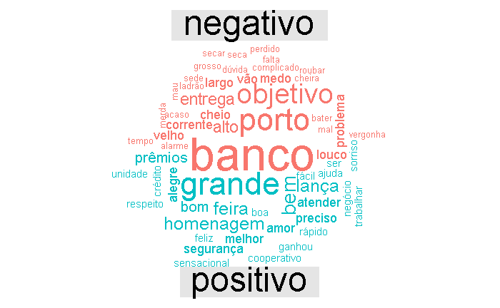

```r
####
#### nuvem de sentimentos
####
library(reshape2)
library(wordcloud)
sentJoin %>%
  count(word, sentimento, sort = TRUE) %>%
  acast(word ~ sentimento, value.var = "n", fill = 0) %>%
  comparison.cloud(colors = c("#F8766D", "#00BFC4"),
                   max.words = 60)
```

```r
## extra
# sentimentos mais negativos
bottom8tw <- head(sentJoin %>%
                    count(document, sentimento) %>%
                    spread(sentimento, n, fill = 0) %>%
                    mutate(score = positivo - negativo) %>%
                    arrange(score),8)['document']
twdf %>% filter(id %in% as.vector(bottom8tw$document))
```

| tweet | whois | id |
| --- | --- | --- |
| I m at Banco Sicredi in Dom Pedrito RS | semtag | 30 |
| Gerente de Negócios PJ Porto Nacional TO Sicredi Location Porto Nacional TO BR Obj | semtag | 35 |
| meu cartão do Sicredi não chega logo e eu tenho que ficar indo naquela merda pegar fila pra sacar dinheiro que saco | semtag | 89 |
| depois do dia que eu e meu pai disparamos o alarme do sicredi me cago de medo de deixar fechar a porta e passar por isso novamente | sicredi | 103 |
| VELHO OESTE Sicredi de Quatro Marcos é roubado Jornal Oeste | semtag | 112 |
| A sicredi cheira aquelas saboneteiras suspensas que giravam no ar com aquele sabonete PODRE rosa | sicredi | 167 |
| Recebi um sms do sicredi dizendo que o sicredi n manda sms fiquei c medo mais q roubar meus pila de lá não vão kkkk | sicredi | 228 |
| Não existe banco mais ladrão que o sicredi | banco | 233 |

```r
#positivos
top8 <- head(sentJoin %>%
               count(document, sentimento) %>%
               spread(sentimento, n, fill = 0) %>%
               mutate(score = positivo - negativo) %>%
               arrange(desc(score)),8)['document']
twdf %>% filter(id %in% as.vector(top8$document))
```

| tweet | whois | id |
| --- | --- | --- |
| Agora Marau tem três agências do Sicredi! Nova unidade foi inaugurada nesta segunda feira e está localizada na Avenida J | agencia | 100 |
| Agora Marau tem três agências do Sicredi! Nova unidade foi inaugurada nesta segunda feira e está localizada na Ave | agencia | 125 |
| Sicredi lança filme em homenagem ao Dia dos Namorados | semtag | 126 |
| Sicredi lança filme em homenagem ao Dia dos Namorados | semtag | 132 |
| Inaugurou hoje a nova Agência Sicredi Marau Sul! Espaço amplo e moderno que busca valorizar ainda mais a presença | semtag | 134 |
| Sicredi lança filme em homenagem ao Dia dos Namorados Hora | semtag | 147 |
| Sicredi lança filme em homenagem ao Dia dos Namorados | semtag | 166 |
| Ngm leva fé quando digo que o sicredi é o melhor banco pra ter conta mas bah sempre sou tão bem atendida quando | melhor | 220 |

## analise de sentimento usando sentR

Tambem usei a biblioteca sentR para analisar os sentimento dos tweets. Esta biblioeta utiliza Naive Bayes para a classificação. Vamos verificar como o algoritmo classifica os tweets.

```r
#install_github('mananshah99/sentR')
require(sentR)
sentimentToScore <-  sample_n(data.frame(text=twdf$tweet),100)
#Aplicando o metodo de classificação Naive Bayes
out <- classify.naivebayes(sentimentToScore$text)
scoredDf <- cbind(sentimentToScore,out, stringsAsFactors=F)
scoredDf$`POS/NEG` <- as.numeric(scoredDf$`POS/NEG`)
s <-head(scoredDf %>% arrange(`POS/NEG`) %>% select(text),10)
#negativas
s[,1]
```

```
 [1] Na frente do sicredi mane  perto de onde nos corrimo deles aquele dia kkkkk
 [2] under the hood of Woop Sicredi
 [3] Sicredi  Analista de Comunicação e Mar
 [4] Alo moça que trabalha no sicredi da meia praia
 [5] Faz um empréstimo no Sicredi negro  é rápido e fácil  com juros muito pequenos que cabem no seu bolso
 [6] Tá passando por algum problema financeiro ou tem alguma dúvida? Assista nosso vídeo  fique ligado na dica do nosso
 [7] Analista de Comunicação e Marketing   Sede I Nova Petrópolis RS
 [8] Quer participar de uma equipe dinâmica que contribui diariamente na criação de produtos incríveis que afetam milhõe
 [9] Sicredi lança filme em homenagem ao Dia dos Namorados
[10] O goiano cooperado do Sicredi que ganhou viagem com tudo pago para Copa da Rússia
232 Levels: A   em parceria com a Mauricio de Sousa Produções  criou uma série especial dos quadrinhos da Turma da Môn ...
```

```r
#mais positivas
s<-head(scoredDf %>% arrange(desc(`POS/NEG`)) %>% select(text),10)
s[,1]
```

```
 [1] Sicredi sempre cheio de gente  na por favor
 [2] Uma ação simples mas de alto impacto para quem vivenciou  Parabéns Sicredi Vale do Rio Pardo!
 [3] A   em parceria com a Mauricio de Sousa Produções  criou uma série especial dos quadrinhos da Turma da Môn
 [4] TCHAU SICREDI GRAÇAS A DEUS NESSA BUCETA  até amanhã te amo fica bem e n esteja cheio amanhã
 [5] Mais uma grande novidade Sicredi
 [6] Um fim de semana muito especial! Fomos convidados para falar sobre o corpo humano e saúde no evento da Sicredi Alia
 [7] Dia da Cooperação terá atividades físicas com concentração na Praça Honorato  em Cachoeira do Sul  no dia   Promo
 [8] Sicredi  Operador I   Porto Alegre  RS   Porto Alegre  Río Grande del Sur
 [9] Estagiário   Sicredi Várzea Grande  Sicredi  Location   Várzea Grande MT BR O Sicredi de
[10] Precisa de ajuda com o seu negócio? Abra uma conta corrente com o Sicredi e conte com o portfólio de soluções  Conf
232 Levels: A   em parceria com a Mauricio de Sousa Produções  criou uma série especial dos quadrinhos da Turma da Môn ...
```

## Outra biblioteca: sentimentAnalisys

Esta biblioteca tambem realiza a analise de sentimento. Vamos verificar como ficou o resultado.

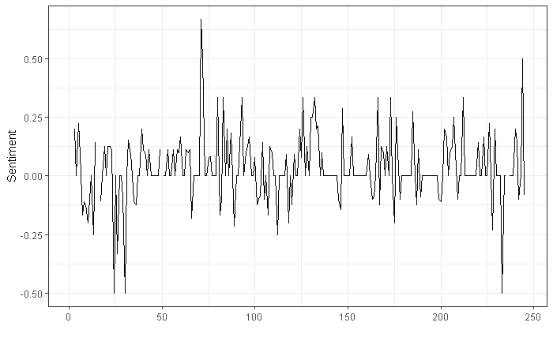

```r
##
#pacote sentimentAnalisys
install.packages("SentimentAnalysis")
library(SentimentAnalysis)
dictionaryPortuguese <- SentimentDictionaryBinary(positivas$word,
                                                  negativas$word)
twdf$id <- row.names(twdf)
sentiment <- analyzeSentiment(twdf$tweet,
                              language="portuguese",
                              rules=list("PtSentiment"=list(ruleSentiment, dictionaryPortuguese),
                                         "Ratio"=list(ruleSentimentPolarity,dictionaryPortuguese),
                                         "Words"=list(ruleWordCount)))
#sentiment
plotSentiment(sentiment)
```

## Conclusão

A linguagem R se mostrou muito poderosa para vizualiação dos dados. Comparando ao python, demonstrou ser mais eficiente. A análise de sentimento em Pt-Br ainda é complicada e isso deve ser considerado. Ainda é um nicho a ser explorado pela comunidade e não temos muitas bibliotecas alimentadas com o portugues, e por vezes foi verificado uma análise incorreta do sentimento do tweet.